# Splines for Estimating Shape of Regression Functions

```r
library(tidyverse)
library(Hmisc)
library(rms)
library(splines)
library(car)
library(MASS)
library(lspline)
#
setwd("~/Dropbox/GitHub/Class2020")
# loading the HERS data set from Vittinghoff's data
hers <- read_csv("DataRegressBook/Chap3/hersdata.csv")
```

## Linear Splines

The simplest spline function is the linear spline function, a piecewise linear function. The assumption is that the $x$ axis is divided into intervals wit hend points at $a, b,$ and $c$, called knots. The linear spine function is defined by
$$f(X) = \beta_0 + \beta_1 X + \beta_2 (X-a)_+ + \beta_3 (X-b)_+ + \beta_4 (X-c)_+$$
where
$$(u)_+ = u, u>0,$$
$$= 0, u \leq 0$$
The general linear model can be written assuming only piecewise linearity in X

$$X \beta = \beta_0 + \beta_1 X_1 + \beta_2 X_2 + \beta_3 X_3 + \beta_4 X_4$$
and
$$X_1 = X , X_2 = (X-a)_+ , X_3 = (X-b)_+ , X_4 =(X-c)_+$$

## Cubic Spline Functions

Cubic polinomials have been found tohave nice properties with good ability to fit sharply curving shapes. Cubic splines can be made to be smooth at the joint points(knots), by forcing the first and second derivatives of the function to agree at the knots:
$$f(X) = \beta_0 + \beta_1 X + \beta_2 X^2 + \beta_3 X^3 + \beta_4 (X-a)^{3}_+ + \beta_5 (X-b)^{3}_+ + \beta_6 (X-c)^{3}_+$$

## Restricted Cubic Splines

Cubic splines behave poorly at the tails, that is before the first knot and after the last knot. Natural splines $ns$ or restricted cubic spline function constrain the function to be linear at the tails

$$f(X) = \beta+0 + \beta_1 X_1 + \beta_2 X_2 + \cdots + \beta_{k-1} X_{k-1}$$

where $X_1 = X$ and for $j= 1, \dots ,k-2$,

$$X_{j+1} = (X - t_j)^{3}_+ - (X - t_{k-1})^{3}_+(t_k - t_j)/(t_k - t_{k-1}) + (X - t_k)^{3}_+(t_{k-1} - t_j)/(t_k - t_{k-1})$$
in the Hmisc and rms functions the terme in the last equation are scaled divided by $\tau = (t_k - t_1)^2$

For the HERS data plotting the LDL and HDL variables vs. BMI we get

```r
# to prepare the HERS data adding variables
hers <- mutate(hers, statins = factor(statins))
hers <- mutate(hers, nonwhite = factor(nonwhite))
hers <- mutate(hers, smoking = factor(smoking))
hers <- mutate(hers, drinkany = factor(drinkany))
# centering and other manipulations
hers <- mutate(hers, BMIc = BMI - mean(BMI, na.rm=TRUE))
hers <- mutate(hers, BMIc2 = BMIc^2)
hers <- mutate(hers, agec = age - mean(age, na.rm= TRUE))
#
hers_no_statins <- mutate(hers, statins = "no", na.rm=TRUE)
hers_statins <- mutate(hers, statins = "yes", na.rm=TRUE)
#
```

```r
# TABLE 4.20 and the model check
HDL_model_BMIc2 <- lm(HDL ~ BMIc + BMIc2 + agec + nonwhite + smoking + drinkany, data=hers)
S(HDL_model_BMIc2)
```

```
Call: lm(formula = HDL ~ BMIc + BMIc2 + agec + nonwhite + smoking + drinkany,
         data = hers)

Coefficients:
             Estimate Std. Error t value Pr(>|t|)
(Intercept) 47.800010   0.380769 125.535  < 2e-16 ***
BMIc        -0.527243   0.050766 -10.386  < 2e-16 ***
BMIc2        0.024253   0.005323   4.556 5.44e-06 ***
agec         0.189321   0.038035   4.978 6.84e-07 ***
nonwhiteyes  2.494766   0.781573   3.192  0.00143 **
smokingyes  -2.070298   0.744909  -2.779  0.00549 **
drinkanyyes  4.345096   0.504141   8.619  < 2e-16 ***
---
Signif. codes:  0 '***' 0.001 '**' 0.01 '*' 0.05 '.' 0.1 ' ' 1

Residual standard deviation: 12.66 on 2738 degrees of freedom
  (18 observations deleted due to missingness)
Multiple R-squared: 0.08058
F-statistic: 39.99 on 6 and 2738 DF,  p-value: < 2.2e-16
     AIC      BIC
21736.11 21783.45
```

```r
confint(HDL_model_BMIc2)
```

```
                  2.5 %     97.5 %
(Intercept) 47.05338599 48.5466339
BMIc        -0.62678682 -0.4276985
BMIc2        0.01381497  0.0346904
agec         0.11474136  0.2639005
nonwhiteyes  0.96223255  4.0272987
smokingyes  -3.53093797 -0.6096584
drinkanyyes  3.35656126  5.3336314
```

## Checking Model Assumptions and Fit

### Linearity

Departures from linearity could be carried out using LOESS. If the linear fit were satisfactory, the LOESS curve would be close to the model regression line.

The most precise evaluation is isong the residuals $r_i = y_i - \hat{y_i}$. Te basic idea is plot the residuals versus each of the continuous predictors in the model; then a non-parametric smoother is used to detect departures from a linear trnd in the average (zero, if centered) value of the residuals acroos the values of the predictor. **This is a residual versus predictor (RVP) plot**.

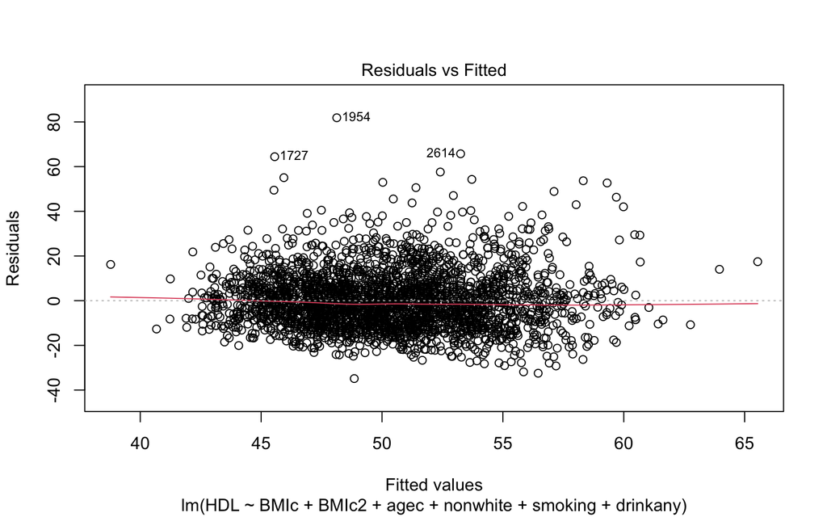

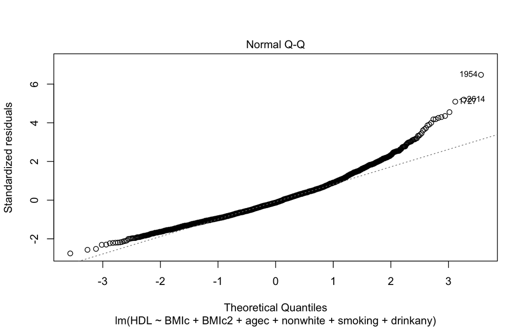

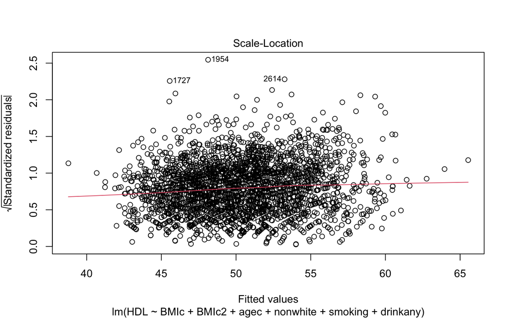

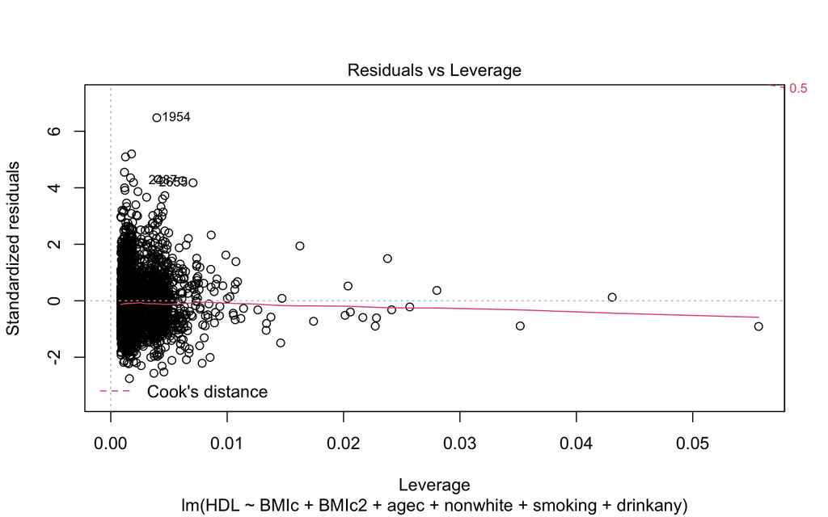

```r
plot(HDL_model_BMIc2)
```

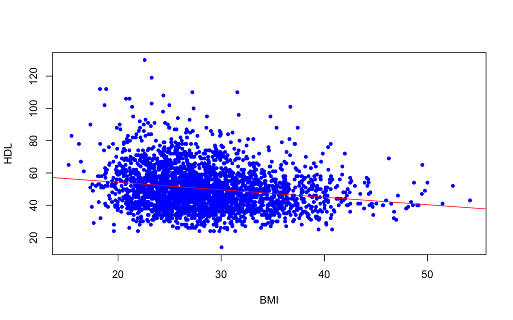

```r
## Comparing simpler models of the same data.
LDL_simpModel <- lm(LDL ~ BMI, data= hers)
HDL_simpModel <- lm(HDL ~ BMI, data= hers)

plot(HDL ~ BMI, pch= 20, col= "blue", data=hers)
abline(coef=coef(HDL_simpModel), col="red")
```

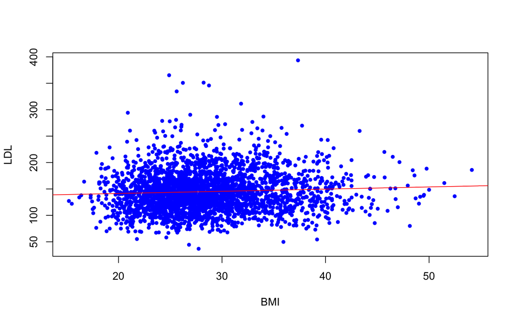

```r
#
plot(LDL ~ BMI, pch= 20, col= "blue", data=hers)
abline(LDL_simpModel, col="red")
```

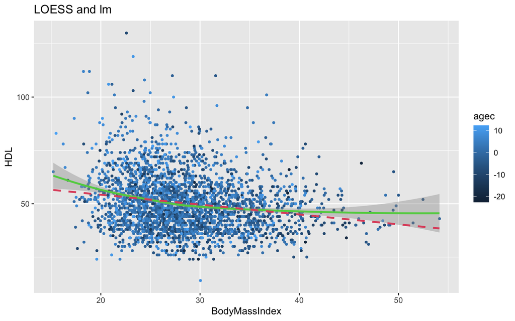

```r
#

# FIGURE 4.5
ggplot(data = hers, mapping=aes(y=HDL, x=BMI, color=agec)) +
  labs(x="BodyMassIndex", y= "HDL", title = "LOESS and lm") +
  geom_point(shape=20, na.rm=TRUE) +
  geom_smooth(method="loess", color= 3, na.rm=TRUE) +
  geom_smooth(method="lm", color= 2, linetype=2, na.rm=TRUE, se=FALSE)
```

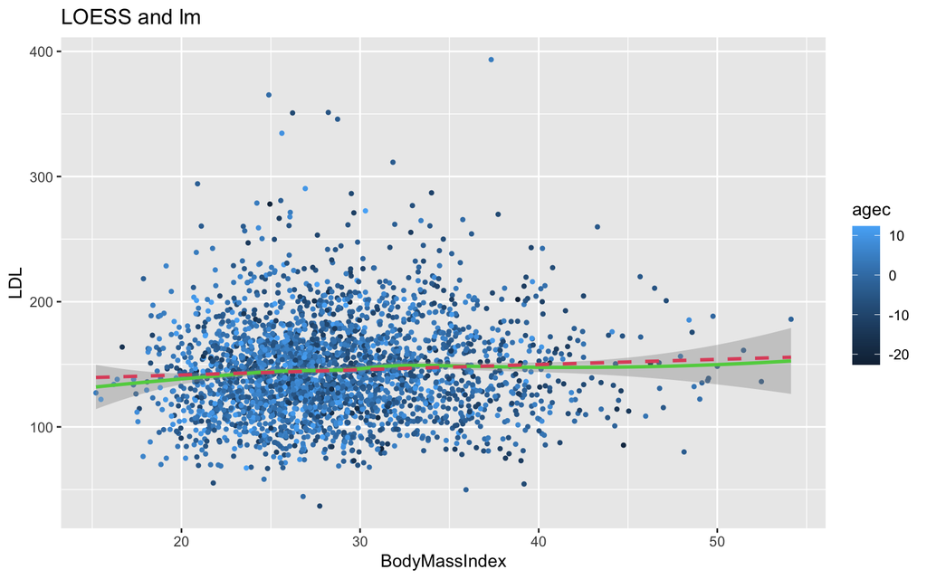

```r
# And the plots are here
ggplot(data = hers, mapping=aes(y=LDL, x=BMI, color=agec)) +
  labs(x="BodyMassIndex", y= "LDL", title = "LOESS and lm") +
  geom_point(shape=20, na.rm=TRUE) +
  geom_smooth(method = "loess", color= 3, na.rm=TRUE) +
  geom_smooth(method="lm", formula=y~x, color= 2, linetype= 2, na.rm=TRUE, se=FALSE)
```